# Session 2: Recap Regression Analysis

Laura Eberlein, Santiago Gómez-Echeverry & Dimitris Pavlopoulos

2022-11-21

# Setting up

The idea of this practical is to go through the basics of multiple regression analysis, which you should know from previous courses.

Before diving into the core of the lecture, remember that you should always start your R session by arranging the work space.

```r
# Clean the environment
rm(list = ls())

# Setting the working directory
setwd("C:/Users/Startklar/OneDrive - Vrije Universiteit Amsterdam/Measurement Models in Quantitative Research/3 - Practicals/Meas_Models")

# Installing  and loading the required packages
library(ggplot2)
library(car)
library(lsr)
library(skedastic)
library(MASS)
```

# Regression Modeling

Now, we can go back to our topic. The main idea behind regression is that a dependent variable (DV) can be modeled as a combination of a single or multiple independent variables (IV). For example, we could model a variable $y_{i}$ as the weighted sum of $k$ independent variables, denoted by $x_{i}$, and an error term $\varepsilon_{i}$. Note that in this notation $i$ refers to an individual. Thus, we have a population model of the form:

$$\begin{aligned}
y_{i} = \beta_{0} + \beta_{1}x_{1i}+...+\beta_{k}x_{ki} +
\varepsilon_{i}
\end{aligned}$$

Keep in mind that this model is the basis of many other and that frequently, in all of them, we use greek letters to refer to parameters and latin letters to refer to variables. Based on this model, which we assume shows the real behavior of the variables in the population, we estimate the unknown parameters and with them obtain the expected value of $y_{i}$.The expected value of $y_{i}$,also referred as the estimated model, is termed as:

$$\begin{aligned}
E[y_{i}|x_{1i}...x_{ki}] = \hat{\beta_{0}} +
\hat{\beta_{1}}x_{1i}+...+\hat{\beta_{k}}x_{ki}
\end{aligned}$$

But, wait, we didn’t really talk about how we obtain the estimates of the parameters. Although there are several ways of doing this, the most frequently used is to perform Ordinary Least Squares (OLS). The OLS estimators are obtained by minimizing the sum of the square of the residuals (the estimated errors).

$$\begin{aligned}
Min \sum_{i=i}^{n}\hat{\varepsilon_{i}}^{2} = \sum_{i=i}^{n}(y_{i} -
E[y_{i}|x_{1i}...x_{ki}])^{2}
\end{aligned}$$

Standard statistical modeling takes a closer inspection on the parameters since they give us information on the relationships between the variables. On the other hand, machine learning approaches focus on the expected value of the variable of interest since the objective there is to predict the value of a determined variable

## Assumptions

### 2 - Exogeneity - $E(\varepsilon_{i}|x_{i})=0$

This is equivalent to saying $Cov(\varepsilon_{i}, x_{i}) = 0$, which implies that there is no part of the error that correlates with the explanatory variables. There are several issues that can make this assumption not feasible:

- Omitted Variable
- Reverse Causality
- Measurement Error
- Selection Bias

Keep in mind that this assumptions must hold for us to be able to say that the we are observing a *causal* effect of $x_{i}$ on $y_{i}$. Thus, achieving this is the focus of fields as impact evaluation.

### 3 - Absence of influential outliers

As you saw in the equations at the beginning of this lesson, regression analysis is built on the concept of average (that’s why we used the $E[y_{i}|.]$).

### 4 - Lack of perfect multicollinearity

### 5 - Homoscedasticity

Also know as homogeneity of variance, this assumption entails that the variance of the errors is constant across the IV’s. In other words, if we plot the residuals against our independent variables, and check two different points of the IV, the variance of the residuals shall be equivalent. This sounds a bit convoluted but maybe a plot might help to see the distinction between homoscedasticity and heteroscedasticity.

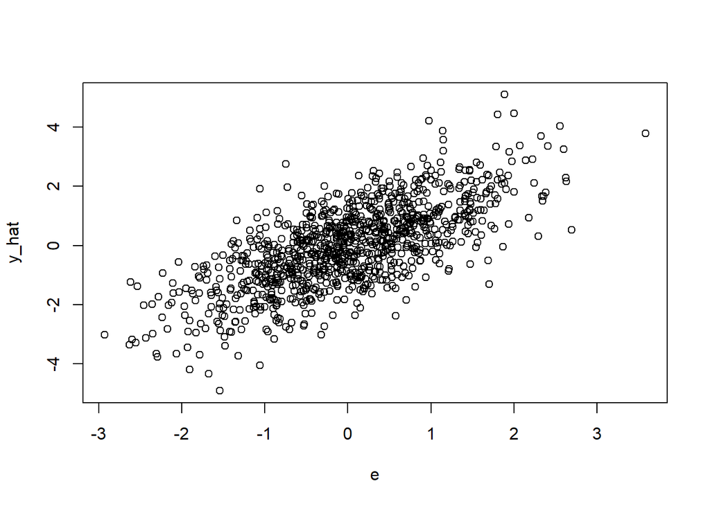

```r
set.seed(42)

# Homoscedasticity
n <- 1000
a <- 0; b <- 1
x <- rnorm(n, mean = 0, sd = 1)
e <- rnorm(n, mean = 0, sd = 1)
y_hat <- a + b*x + e
plot(e, y_hat)
```

```r
# Heteroscedasticity
n <- 1000
a <- 0; b <- 1
e_het <- rnorm(n, mean = 0, sd = (1+0.4*x))
```

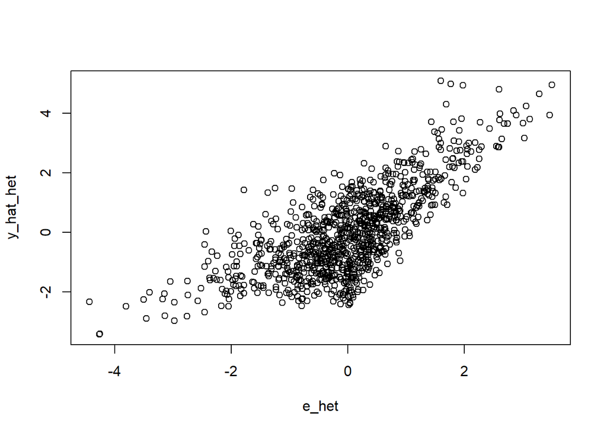

```r
y_hat_het <- a + b*x + e_het
plot(e_het, y_hat_het)
```

# Example - Birth weight

```r
data(birthwt, package = "MASS")

# Let's check what this data has
head(birthwt)
```

```
##    low age lwt race smoke ptl ht ui ftv  bwt
## 85   0  19 182    2     0   0  0  1   0 2523
## 86   0  33 155    3     0   0  0  0   3 2551
## 87   0  20 105    1     1   0  0  0   1 2557
## 88   0  21 108    1     1   0  0  1   2 2594
## 89   0  18 107    1     1   0  0  1   0 2600
## 91   0  21 124    3     0   0  0  0   0 2622
```

```r
?birthwt
```

## Simple regression - Continuous IV

Our goal with this data will be to estimate children weight at birth. To do so, we can first just employ age as an IV and see our results. Beforehand though, let us see a scatter with these two variables

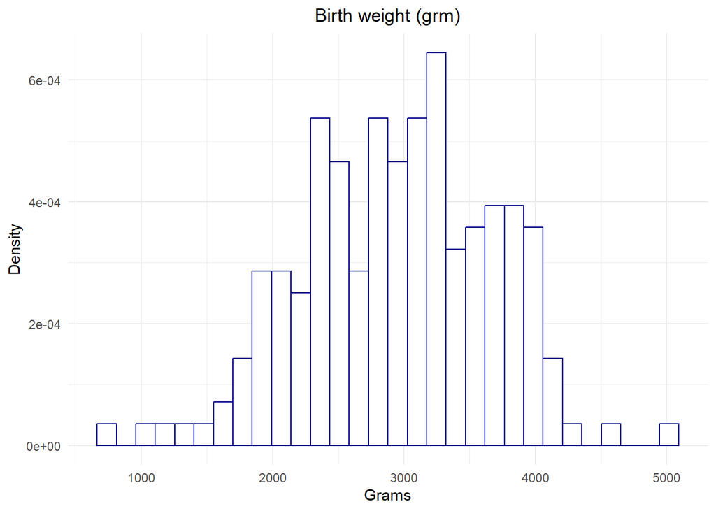

```r
# Individual variables
ggplot(data = birthwt, aes(bwt)) +
  geom_histogram(aes(y = after_stat(density)), color = "darkblue", fill = "white") +
  theme_minimal() +
  labs(title = "Birth weight (grm)", y = "Density", x = "Grams") +
  theme(plot.title = element_text(hjust = 0.5))
```

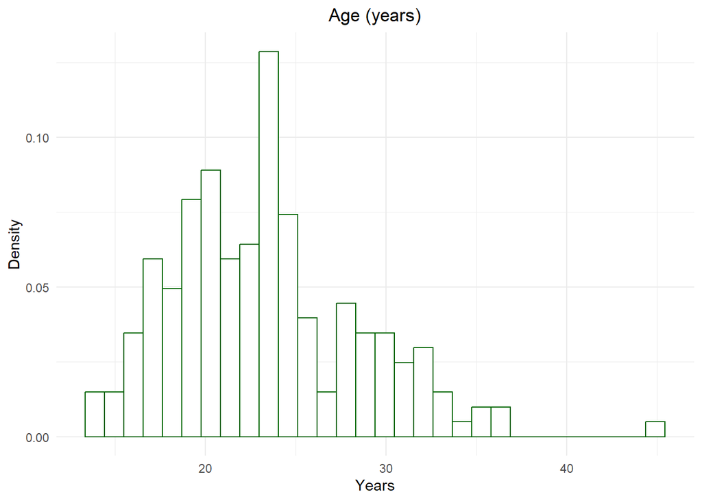

```r
ggplot(data = birthwt, aes(age)) +
  geom_histogram(aes(y = after_stat(density)), color = "darkgreen", fill = "white") +
  theme_minimal() +
  labs(title = "Age (years)", y = "Density", x = "Years") +
  theme(plot.title = element_text(hjust = 0.5))
```

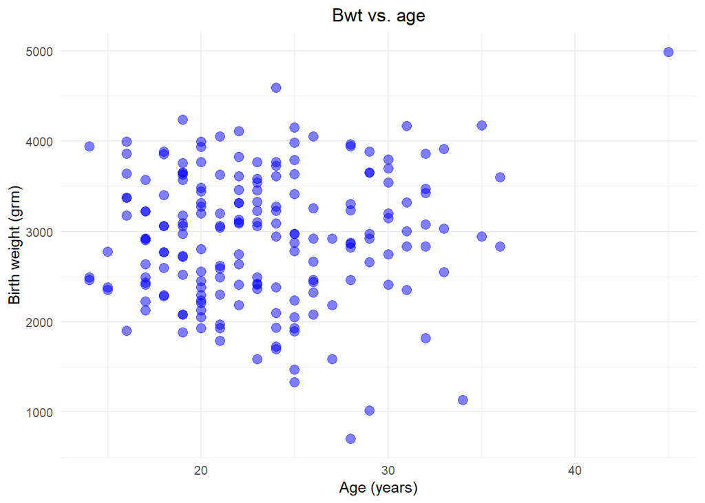

```r
# Scatter plot
ggplot(data = birthwt) +
  geom_point(aes(y = bwt, x = age), color = "blue", size = 3, alpha = 0.5) +
  theme_minimal() +
  labs(title = "Bwt vs. age", y = "Birth weight (grm)", x = "Age (years)") +
  theme(plot.title = element_text(hjust = 0.5))
```

```r
# Perform the regression
reg1 <- lm(bwt ~ age, data = birthwt) # lm stands for linear model
#reg1_alt <- glm(bwt ~ age, data = birthwt, family = "gaussian") # glm stands for generalized linear model

# Check the results
summary(reg1)
```

```
##
## Call:
## lm(formula = bwt ~ age, data = birthwt)
##
## Residuals:
##      Min       1Q   Median       3Q      Max
## -2294.78  -517.63    10.51   530.80  1774.92
##
## Coefficients:
##             Estimate Std. Error t value Pr(>|t|)
## (Intercept)  2655.74     238.86   11.12   <2e-16 ***
## age            12.43      10.02    1.24    0.216
## ---
## Signif. codes:  0 '***' 0.001 '**' 0.01 '*' 0.05 '.' 0.1 ' ' 1
##
## Residual standard error: 728.2 on 187 degrees of freedom
## Multiple R-squared:  0.008157,   Adjusted R-squared:  0.002853
## F-statistic: 1.538 on 1 and 187 DF,  p-value: 0.2165
```

```r
#summary(reg1_alt)
```

The results include:

*Residuals distribution*

*Information on coefficients*

*Residual standard error*

*F-statistic*

*Adjusted R-squared*

Now, to end with this part, let us see the scatter plot again but now including our linear estimate.

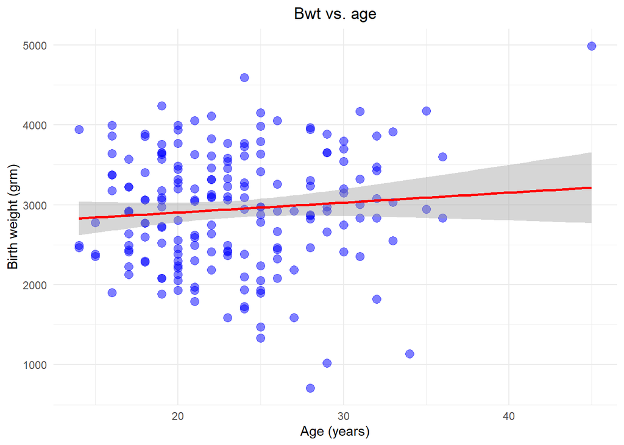

```r
plot1 <- ggplot(data = birthwt, aes(y = bwt, x = age)) +
  geom_point(color = "blue", size = 3, alpha = 0.5) +
  stat_smooth(method = "lm", col = "red") +
  theme_minimal() +
  labs(title = "Bwt vs. age", y = "Birth weight (grm)", x = "Age (years)") +
  theme(plot.title = element_text(hjust = 0.5))
plot1
```

## Simple regression - Dummy IV

The interpretation of the regression results vary considerably when we are dealing with IV’s that are dummies. We can see this by regressing the birth weight against the dummy variable that indicates whether the mother smoked (0 = Didn’t Smoke, 1 = Smoked).You’ll frequently encounter dummy variables since they are a common way of representing the presence/absence of a trait. Still, for including this variables in a regression analysis you must be sure that it is coded as 0 and 1; a common coding for these variables in surveys is 1 and 2 so you might have to recode it.

```r
# Perform the regression
reg2 <- lm(bwt ~ smoke, data = birthwt)

# Check the results
summary(reg2)
```

```
##
## Call:
## lm(formula = bwt ~ smoke, data = birthwt)
##
## Residuals:
##     Min      1Q  Median      3Q     Max
## -2062.9  -475.9    34.3   545.1  1934.3
##
## Coefficients:
##             Estimate Std. Error t value Pr(>|t|)
## (Intercept)  3055.70      66.93  45.653  < 2e-16 ***
## smoke        -283.78     106.97  -2.653  0.00867 **
## ---
## Signif. codes:  0 '***' 0.001 '**' 0.01 '*' 0.05 '.' 0.1 ' ' 1
##
## Residual standard error: 717.8 on 187 degrees of freedom
## Multiple R-squared:  0.03627,    Adjusted R-squared:  0.03112
## F-statistic: 7.038 on 1 and 187 DF,  p-value: 0.008667
```

```r
# Perform the ANOVA
aov1 <- aov(bwt ~ smoke, data = birthwt)

# Check the results
summary(aov1)
```

```
##              Df   Sum Sq Mean Sq F value  Pr(>F)
## smoke         1  3625946 3625946   7.038 0.00867 **
## Residuals   187 96343710  515207
## ---
## Signif. codes:  0 '***' 0.001 '**' 0.01 '*' 0.05 '.' 0.1 ' ' 1
```

```r
# However, in ANOVA, there is a strong culture on presenting effect sizes by measures as eta
etaSquared(aov1)
```

```
##           eta.sq eta.sq.part
## smoke 0.03627047  0.03627047
```

The coefficient $\beta = -283.78, t = -2.653, p = 0.008$ represents the difference between the smoker and the non smoker mothers in terms of the birth weight of their children measured in grams. Thus, we can state that the children of mothers who have smoked weigh, on average, -283.78 grams less than the children from non smoking moms.

## ‘Multiple’ regression - Categorical IV (factors in R)

When dealing with categorical variables in a regression, the interpretation of the coefficients also change. Moreover, we need to keep in mind that since the numbers in categorical variables don’t have a proper algebraic value we can’t just include them in the regression; we will use a set of dummy variables, one corresponding to each category. For instance, let’s assume that we have a categorical variable for life satisfaction with 4 possible responses: Very Dissatisfied (VD), Dissatisfied (D), Satisfied (S), Very Satisfied (VS). This is what is frequently termed as a Likert Scale. Given the aforementioned, we cannot simply include the categorical variable as it is (i.e., the jump from VD to D is not the same as from D to S), instead we want to include one dummy for each satisfaction level. However, if we include all the dummy variables the problem won’t be computable since we have perfect multicollinearity; if we have information on the first three response categories we know entirely how the last category is going to behave. Thus, in these situations we will always include c-1 dummy variables, being c the number of categories of our variable of interest. The indicator that is not included in the regression is called base category and will be the guiding level for the interpretation of the results

Let’s see with a bit more detail how this works with our example on birth weight. Now, we will see the relationship between race and birth weight. To perform this type of regression we need to be certain that R takes our categorical variable as a factor first.

```r
# Transform race into a factor
birthwt$race <- factor(birthwt$race,
                       levels = 1:3,
                       labels = c("White", "Black", "Other") )
is.factor(birthwt$race) # To be certain that is a factor
```

```
## [1] TRUE
```

Having checked that our main IV is a factor we can run our regression.

```r
# Perform the regression
reg3 <- lm(bwt ~ race, data = birthwt)
# Check the results
summary(reg3)
```

```
##
## Call:
## lm(formula = bwt ~ race, data = birthwt)
##
## Residuals:
##      Min       1Q   Median       3Q      Max
## -2096.28  -502.72   -12.72   526.28  1887.28
##
## Coefficients:
##             Estimate Std. Error t value Pr(>|t|)
## (Intercept)  3102.72      72.92  42.548  < 2e-16 ***
## raceBlack    -383.03     157.96  -2.425  0.01627 *
## raceOther    -297.44     113.74  -2.615  0.00965 **
## ---
## Signif. codes:  0 '***' 0.001 '**' 0.01 '*' 0.05 '.' 0.1 ' ' 1
##
## Residual standard error: 714.5 on 186 degrees of freedom
## Multiple R-squared:  0.05017,    Adjusted R-squared:  0.03996
## F-statistic: 4.913 on 2 and 186 DF,  p-value: 0.008336
```

Depending on the situation, we might want to use a different base category for our regression. To do so, we can simply use the function relevel as presented below.

```r
birthwt$race <- relevel(birthwt$race, ref = 2)
# Perform the regression
reg4 <- lm(bwt ~ race, data = birthwt)
# Check the results
summary(reg4)
```

```
##
## Call:
## lm(formula = bwt ~ race, data = birthwt)
##
## Residuals:
##      Min       1Q   Median       3Q      Max
## -2096.28  -502.72   -12.72   526.28  1887.28
##
## Coefficients:
##             Estimate Std. Error t value Pr(>|t|)
## (Intercept)  2719.69     140.12  19.409   <2e-16 ***
## raceWhite     383.03     157.96   2.425   0.0163 *
## raceOther      85.59     165.09   0.518   0.6048
## ---
## Signif. codes:  0 '***' 0.001 '**' 0.01 '*' 0.05 '.' 0.1 ' ' 1
##
## Residual standard error: 714.5 on 186 degrees of freedom
## Multiple R-squared:  0.05017,    Adjusted R-squared:  0.03996
## F-statistic: 4.913 on 2 and 186 DF,  p-value: 0.008336
```

## Multiple regression

```r
# Perform the regression
reg5 <- lm(bwt ~ age + smoke + race, data = birthwt)

# Check the results
summary(reg5)
```

```
##
## Call:
## lm(formula = bwt ~ age + smoke + race, data = birthwt)
##
## Residuals:
##     Min      1Q  Median      3Q     Max
## -2322.6  -447.3    28.4   502.2  1612.3
##
## Coefficients:
##             Estimate Std. Error t value Pr(>|t|)
## (Intercept) 2837.604    257.573  11.017  < 2e-16 ***
## age            2.134      9.771   0.218 0.827326
## smoke       -426.093    109.988  -3.874 0.000149 ***
## raceWhite    444.069    156.194   2.843 0.004973 **
## raceOther     -3.789    161.115  -0.024 0.981264
## ---
## Signif. codes:  0 '***' 0.001 '**' 0.01 '*' 0.05 '.' 0.1 ' ' 1
##
## Residual standard error: 690 on 184 degrees of freedom
## Multiple R-squared:  0.1236, Adjusted R-squared:  0.1046
## F-statistic:  6.49 on 4 and 184 DF,  p-value: 6.592e-05
```

## Checking the assumptions

### 1 - Normality of the residuals.

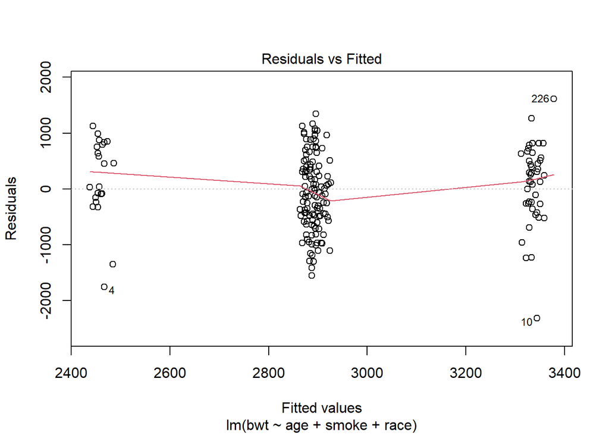

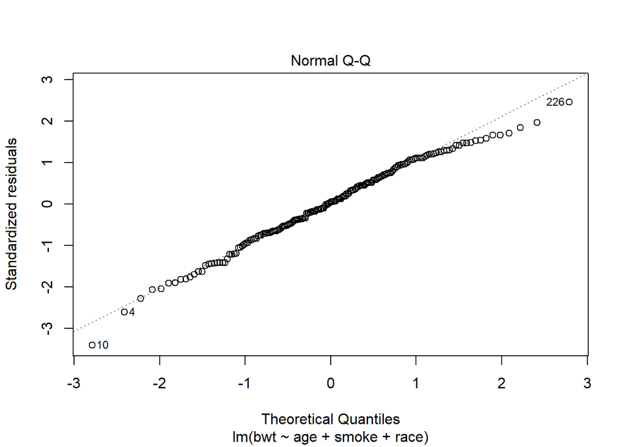

```r
# Checking the normality in the residuals
plot(reg5, which = c(1,2))
```

### 3 - Absence of influential outliers

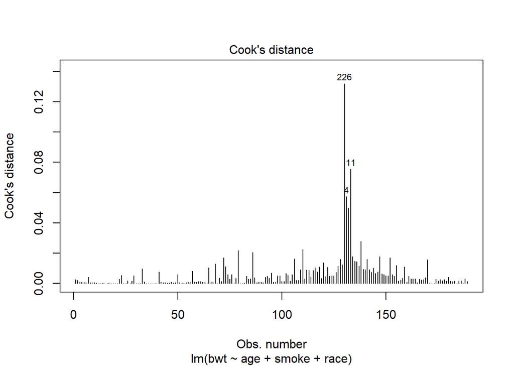

```r
plot(reg5, which = 4) # Direct function to observe the influential observations
```

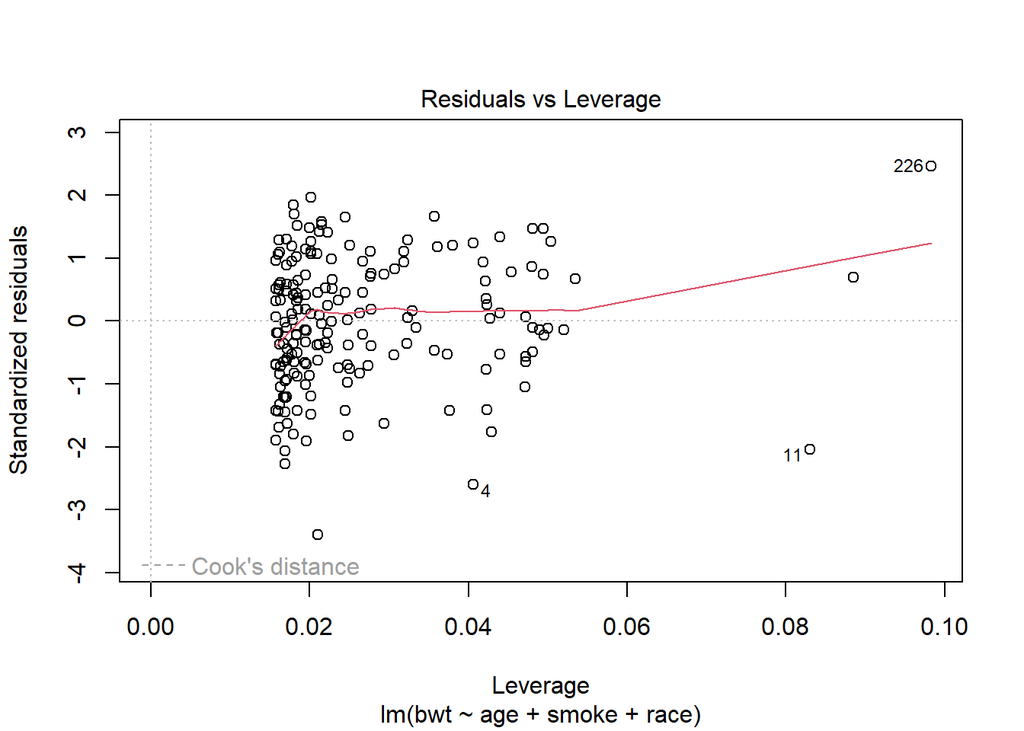

```r
plot(reg5, which = 5)
```

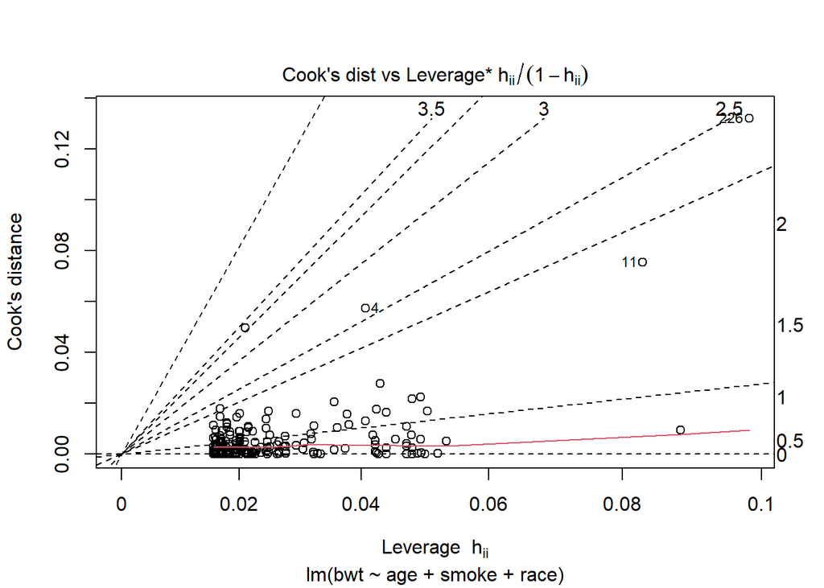

```r
plot(reg5, which = 6)
```

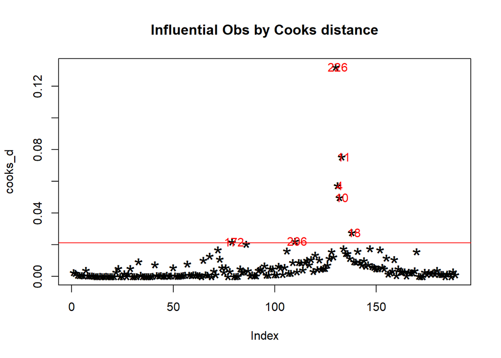

```r
# We could also reproduce this exercise manually with the function cooks.distance()
cooks_d <- cooks.distance(reg5)

# Plot the Cook's Distance using the traditional 4/n criterion
sample_size <- nrow(birthwt)
plot(cooks_d, pch="*", cex=2, main="Influential Obs by Cooks distance")  # plot cook's distance
abline(h = 4/sample_size, col="red")  # add cutoff line
text(x=1:length(cooks_d)+1, y=cooks_d, labels=ifelse(cooks_d>4/sample_size, names(cooks_d),""), col="red")  # add labels
```

```r
# https://ggplot2.tidyverse.org/reference/fortify.lm.html
```

### 4 -Multicollinearity

```r
# Check the correlation between the variables.
#corr()
vif(reg5)
```

```
##           GVIF Df GVIF^(1/(2*Df))
## age   1.058319  1        1.028746
## smoke 1.144015  1        1.069586
## race  1.193803  2        1.045281
```

### 5 - Homoscedasticity

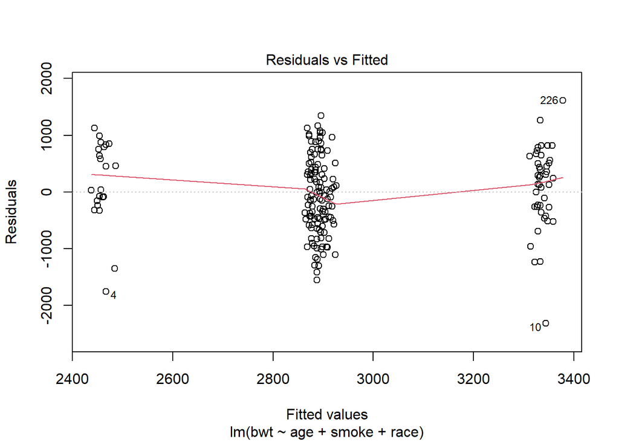

```r
plot(reg5, which = 1)
```

```r
# Breusch-Pagan test
bp <- as.data.frame(breusch_pagan(reg5))
bp
```

```
##   statistic  p.value parameter                method alternative
## 1  5.996256 0.199428         4 Koenker (studentised)     greater
```

```r
# White test
wht <- as.data.frame(white(reg5))
wht
```

```
##   statistic   p.value parameter       method alternative
## 1   7.70142 0.4631662         8 White's Test     greater
```